# Feature Selection Using ‘Boruta’

## Summary

Dimensionality Reduction is highly valuable tool to elicit when using datasets of any size. Let us look at a simple example of how the number of dimension in which our data resides can greatly effect the work needed to done in some cases.

Imagine our data rests on a single dimension number line. In our imaginary dataset we may have 9 data poiints which may rest in 3 units measures, i.e. 9 data points / 3 units measures. Now let us consider that our dataset has a constant number of data points but *NOW* we plan to describe the dataset by using two dimensions. Our current dataset is now spread over 9 units square measures, leaving anywhere from 0 to 8 squares empty. If our dataset now resides in 3-dimensinal space, it is then possible to have 0 to 26 unit cubes empty.

Depending on the data we are investigating, this may impact the work in several ways;

1. There may be an increase in empty blocks in our database. This is known as a sparse matrix.

There are ten common fearture selection methods for R: 1. Boruta 2. Variable Importance from Machine Learning Algorithms 3. Lasso Regression 4. Step wise Forward and Backward Selection *********** 5. Relative Importance from Linear Regression 6. Recursive Feature Elimination (RFE) ******************* 7. Genetic Algorithm 8. Simulated Annealing 9. Information Value and Weights of Evidence 10. DALEX Package Conclusion

See:  
1. https://www.machinelearningplus.com/machine-learning/feature-selection/  
2. https://www.analyticsvidhya.com/blog/2016/03/select-important-variables-boruta-package/  
3. https://www.datacamp.com/community/tutorials/feature-selection-R-boruta  
4. https://www.datasciencecentral.com/profiles/blogs/select-important-variables-using-boruta-algorithm 5. https://www.rdocumentation.org/packages/Boruta/versions/6.0.0/topics/Boruta  
6. https://pypi.org/project/Boruta/

Reference: Miron B. Kursa, Witold R. Rudnicki (2010). Feature Selection with the Boruta Package. Journal of Statistical Software, 36(11), p. 1-13. URL: https://www.jstatsoft.org/article/view/v036i11

### Perform Boruta search

```r
set.seed(1000)
registerDoMC(cores = 3) # Start multi-processor mode
start_time <- Sys.time() # Start timer

boruta_model <- Boruta(Class ~ .,
                       data = c_m_transformed,
                       p = 0.01,
                       mcAdj = TRUE,
                       doTrace = 1)

registerDoSEQ()  # Stop multi-processor mode
end_time <- Sys.time()   # End timer
end_time - start_time    # Display elapsed time
```

```
## Time difference of 14.57552 secs
```

### Display Model Results

- `boruta_model` object details

```r
names(boruta_model)
```

```
##  [1] "finalDecision" "ImpHistory"    "pValue"        "maxRuns"
##  [5] "light"         "mcAdj"         "timeTaken"     "roughfixed"
##  [9] "call"          "impSource"
```

## Variable Importance Scores

```r
roughFixMod <- TentativeRoughFix(boruta_model)

imps <- attStats(roughFixMod)

imps2 = imps[imps$decision != 'Rejected', c('meanImp', 'decision')]

imps2[order(-imps2$meanImp), ]  # descending sort
```

```
##    meanImp  decision
## R 42.27766 Confirmed
## H 33.78392 Confirmed
## C 27.47787 Confirmed
## K 27.36498 Confirmed
## P 27.26580 Confirmed
## E 26.20847 Confirmed
## Y 22.46963 Confirmed
## S 21.33860 Confirmed
## T 21.23638 Confirmed
## A 20.32186 Confirmed
## N 19.73299 Confirmed
## I 18.28795 Confirmed
## F 18.08798 Confirmed
## V 18.00851 Confirmed
## D 17.59688 Confirmed
## G 15.53419 Confirmed
## W 15.39324 Confirmed
## L 14.88342 Confirmed
## M 14.54978 Confirmed
## Q 13.88455 Confirmed
```

### Plot variable importance

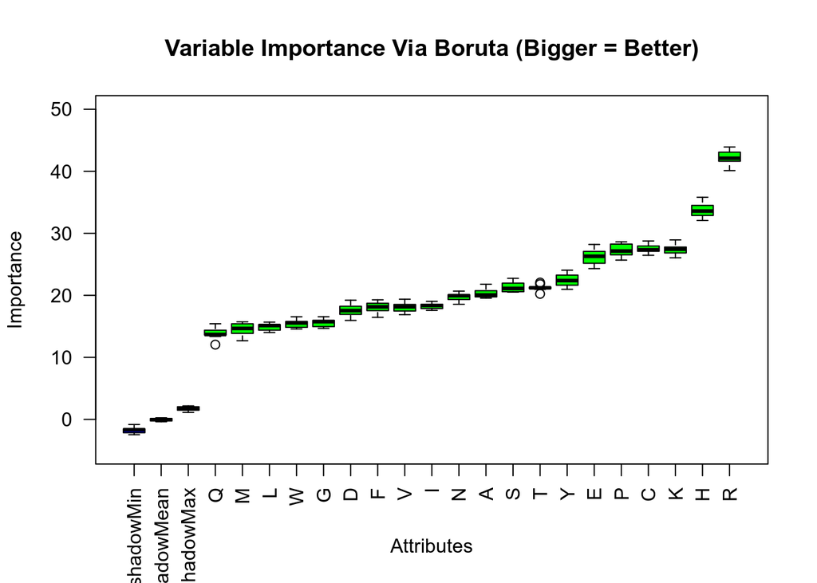